# Data Recodes, Measures of Central Tendency and Variability

Professor Ocampo

February 5, 2026

# Introduction

Hopefully you are becoming more familiar with R, R Studio and R markdown. We will begin working with data more closely now to practice additional tools we are acquiring in class.

First, create a folder `Lab 2` within your `MAS 350C` folder. Set it as your working directory. Then download the lab2.rmd file so you can use it as a template. You can download it from Canvas or from my GitHubpage.

```r
download.file("https://github.com/angelaxocampo/SSM/raw/main/2026/Lab_2/lab2.Rmd", destfile = "lab2.Rmd")
```

Let’s first load (or install) all the necessarily packages. Remember that two of these should all already be installed in your computer. But you need to install a new package called `forecats`. If you need to install any package moving forward just type `install.packages()` and insert the name of the package within the parenthesis with quotation marks.

```r
install.packages("forcats")
```

Load all of the necessary packages.

```r
library(tidyverse)
library(haven)
library(forcats)
```

Let’s now load the data.

```r
LNS <-read_dta(url("https://github.com/angelaxocampo/SSM/raw/main/2026/Lab_1/Data/LNS.dta"))
```

# Summary statistics

Summary statistics help us summarize the data. The function summary returns a numerical summary and some *measures of central tendency*: minimum, first quartile, median, mean, third quartile, maximum.

To calculate the summary statistics for the `AGE` variable type:

```r
LNS %>%
  select(AGE) %>%
  summary()
```

```
##       AGE
##  Min.   :18.00
##  1st Qu.:28.00
##  Median :38.00
##  Mean   :40.52
##  3rd Qu.:51.00
##  Max.   :97.00
##  NA's   :493
```

Since R also functions like a very fancy calculator, you can use these statistics to then calculate the interquartile range (IQR) for the AGE variable. Once the summary function gave us Q_3 and Q_1 we ca use both values for the IRQ.

```r
51-28
```

```
## [1] 23
```

You can use R to create a boxplot of the `AGE` variable.

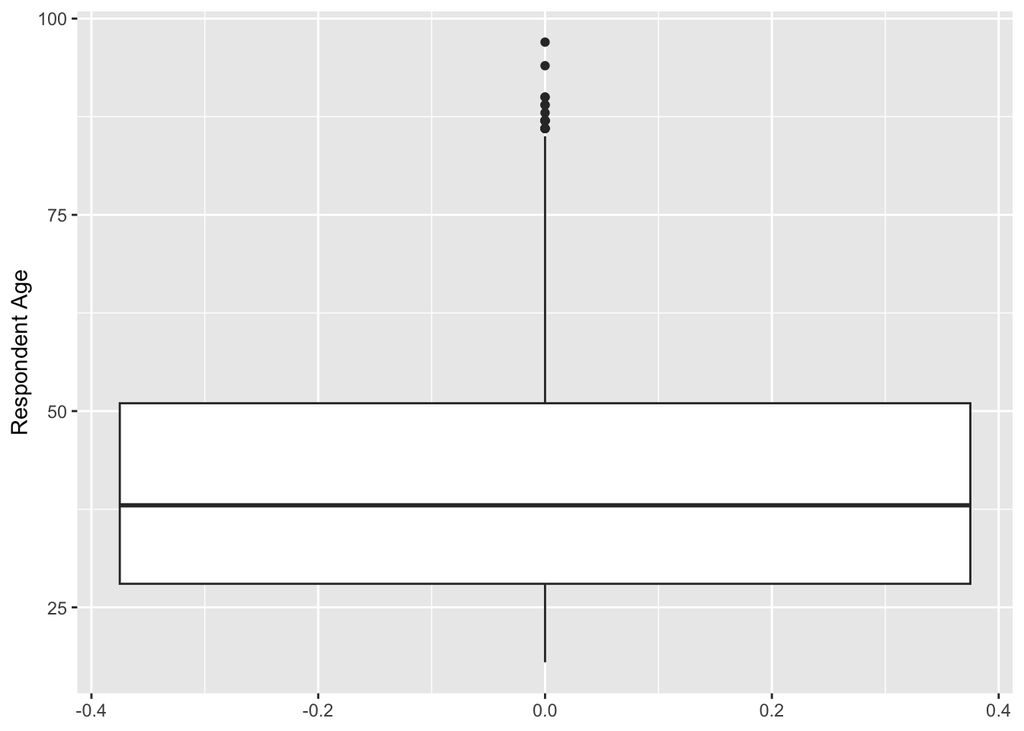

```r
ggplot(LNS, aes(y = AGE)) +
    geom_boxplot(na.rm=T)
```

You can also individually calculate summary statistics, and make your own customized list of them using the summarise function. We are calculating medians, means and standard deviations for the variables `AGE` and `ARRIVEUS`, which are: age of respondents and the year of arrival for Latino respondents who immigrated to the U.S.

```r
 LNS %>%
  summarise(median_age = median(AGE, na.rm=T),
            mean_age = mean(AGE, na.rm=T),
            sd_age = sd(AGE, na.rm=T),
            median_arrive = median(ARRIVEUS, na.rm=T),
            mean_arrive = mean(ARRIVEUS, na.rm=T),
            sd_arrive = sd(ARRIVEUS, na.rm=T))
```

```
## # A tibble: 1 × 6
##   median_age mean_age sd_age median_arrive mean_arrive sd_arrive
##        <dbl>    <dbl>  <dbl>         <dbl>       <dbl>     <dbl>
## 1         38     40.5   15.5          1991       2549.     2047.
```

What do you learn from these?

Okay, let’s say we want to analyze differences across men and women in our sample. We use the function `group_by()`, then use a pipe operator and then use the `summarise()` function. Any patterns?

```r
 LNS %>%
  group_by(SEX) %>%
  summarise(mean_age = mean(AGE, na.rm=T),
            sd_age = sd(AGE, na.rm=T),
            mean_arrive = mean(ARRIVEUS, na.rm=T),
            sd_arrive = sd(ARRIVEUS, na.rm=T))
```

```
## # A tibble: 2 × 5
##   SEX        mean_age sd_age mean_arrive sd_arrive
##   <dbl+lbl>     <dbl>  <dbl>       <dbl>     <dbl>
## 1 1 [MALE]       39.9   15.5       2459.     1888.
## 2 2 [FEMALE]     41.0   15.5       2622.     2166.
```

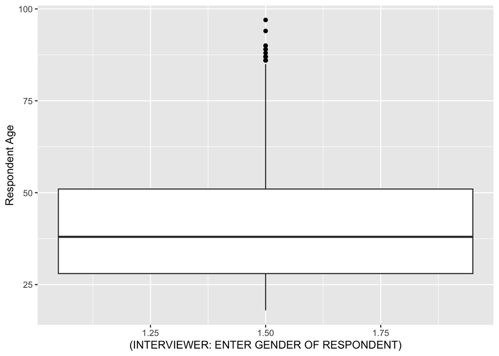

```r
ggplot(LNS, aes(x=SEX, y = AGE, fill=SEX)) +
    geom_boxplot(outlier.colour="black",
                 na.rm=T)
```

What about by nativity (where respondents were born)? Are respondents who were born in the U.S. and those who born in another country or in Puerto Rico differ in age?

```r
 LNS %>%
  group_by(BORNUS) %>%
  summarise(median_age= median(AGE,na.rm=T),
            mean_age = mean(AGE, na.rm=T),
            sd_age = sd(AGE, na.rm=T))
```

```
## # A tibble: 3 × 4
##   BORNUS                 median_age mean_age sd_age
##   <dbl+lbl>                   <dbl>    <dbl>  <dbl>
## 1 1 [Mainland US]                38     40.7   16.6
## 2 2 [Puerto Rico]                55     52.2   16.3
## 3 3 [Some other country]         37     39.4   14.4
```

Some interesting differences!

```r
LNS %>%
  count(RSTATE) %>%
    mutate(pct = prop.table(n) * 100) %>%
    arrange(desc(pct))
```

```
## # A tibble: 18 × 3
##    RSTATE     n    pct
##    <chr>  <int>  <dbl>
##  1 CA      1204 13.9
##  2 TX       811  9.39
##  3 FL       800  9.27
##  4 NY       800  9.27
##  5 IL       600  6.95
##  6 CO       404  4.68
##  7 NJ       403  4.67
##  8 NV       403  4.67
##  9 WA       403  4.67
## 10 AR       401  4.64
## 11 NC       401  4.64
## 12 AZ       400  4.63
## 13 GA       400  4.63
## 14 IA       400  4.63
## 15 NM       400  4.63
## 16 VA       176  2.04
## 17 MD       166  1.92
## 18 DC        62  0.718
```

# Data Recodes

Recoding and cleaning data is one of the most important parts that researchers have to do prior to doing data analysis. Sometimes, we even need to recode data prior to visualizing it (graphing it) and calculating measures of central tendency or variability. You will certainly need to know how to recode data and variables for your final project. We will spend the rest of the lab doing recodes and data cleaning.

Even though a variable may be nominal, sometimes the categories of a variable might be listed as numbers. For example, let’s look at the partisanship variable. When I create a frequency table or a plot of `PARTYID` the categories of this nominal variable show up as 1,2,3,4..etc. Let’s run the code to see that.

```r
LNS %>%
  count(PARTYID) %>%
  mutate(pct = prop.table(n) * 100)
```

```
## # A tibble: 5 × 3
##   PARTYID                        n   pct
##   <dbl+lbl>                  <int> <dbl>
## 1 1 [Democrat]                3085  35.7
## 2 2 [Republican]               970  11.2
## 3 3 [Independent]             1435  16.6
## 4 4 [Don't care]              1410  16.3
## 5 5 [Don't know/other party]  1734  20.1
```

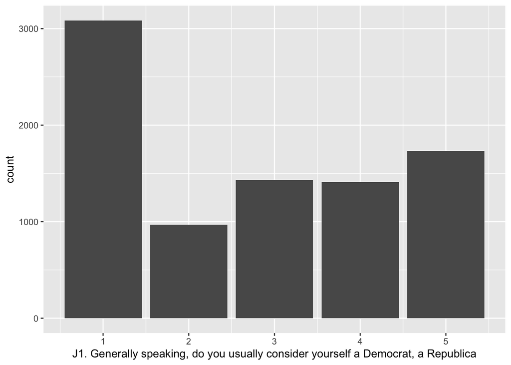

```r
ggplot(LNS, aes(PARTYID)) +
  geom_bar()
```

In this case, we want to recode the variable into a factor, that includes the levels of the nominal variable listed as categories, rather than numbers. Knowing how to recode variables is one of the most important skills in quantitative social science. So try to practice this skill as much as possible. When we begin to do bivariate and multivariate analysis we will need to recode variables in various ways. Sometimes we might need to recode a categorical variable from listed categories back into a variable that might include numbers. We will discuss this later in the semester. For now, let’s recode the `PARTYID` variable using the `mutate()` function, the `case_when()` function. We will also force into a factor, and organize its levels in order so that they can appear in order when we make tables or graphs.

When we recode something, we always want to create a new variable so as to not write over the original variable. So we will create a new variable called `PARTYID_N`. This way, we will know it is the new variable. In the code below, we are telling R to create the new factor variable using code from the old variable, and then replace the number codes into their respective categories. We are also telling it the levels, and by doing so, we are telling it to organize it in this way for us.

```r
LNS <- LNS %>%
  mutate(PARTYID_N =
           case_when(PARTYID == 1 ~ "Democrat",
                     PARTYID == 2 ~ "Republican",
                     PARTYID == 3 ~ "Independent",
                     PARTYID == 4 ~ "Don't care",
                     PARTYID == 5 ~ "Don't know/other party"),
         PARTYID_N = factor(PARTYID_N, levels =
                              c("Democrat", "Republican","Independent",
                                                  "Don't care", "Don't know/other party")))
```

Great, if we now create a bar graph, we can visualize the data much better.

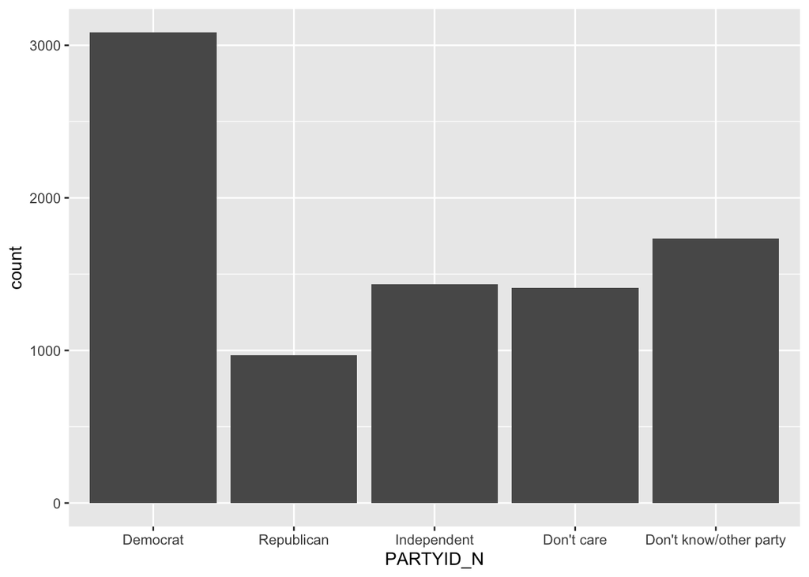

```r
ggplot(LNS, aes(PARTYID_N)) +
  geom_bar()
```

Instead of plotting the raw frequencies we can plot the percentage distribution by using the following code. You would use the same code that you would use for to create frequencies and percentage distributions, then use the pipe operator `%>%` to use that information to create your bar graph. Lastly, you can modify the text or the labels so that it is legible to others and is clear about what the graph represents. We are going to do a 45 degree rotation on the variable label for the x-axis.

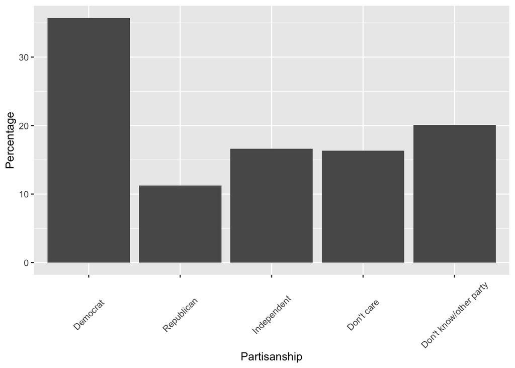

```r
LNS %>%
  count(PARTYID_N) %>%
  mutate(pct = prop.table(n) * 100) %>%
  ggplot(aes(x = PARTYID_N, y = pct)) +
    geom_col() +
  xlab("Partisanship") + ylab("Percentage") +
  theme(axis.text.x = element_text(angle=45, vjust = .5))
```

# On your own

(1.) (a.) Calculate summary statistics for the number of individuals that live in a person’s household in the LNS. (Hint: the variable is called `HOUHOLD`) (b.) Calculate the interquartile range for the no. of individuals in a person’s household. (c.) Create a box plot for this variable.

(2.) (a.) Create a histogram of the number of children that respondents have. How would you describe this distribution? (Hint: `NUMKIDS` is the variable name.) (b.) Calculate the median, mean and standard deviation for the number of children for respondents in the LNS.

(3.) (a.) Create a bar graph displaying the percentage distribution of the income variable in order from lowest to highest level. (b) Describe what type of distribution it is and explain how you know this. (Hint: to do this, you will need to recode income `HHINC` by recoding the numeric values into actual categories arranged in order.)

# Sources

- Garcia-Rios. Puzzle Solving with Data. https://garciarios.github.io/govt_3990/index.html
- R Studio User guide: https://docs.posit.co/ide/user/ide/guide/ui/ui-panes.html
- R for Data Science:https://r4ds.hadley.nz/intro